# ggplot_tutorial

- **Authors**: Catrina Loucks
- **Research field**: Genetics
- **Lesson Topic**: In this lesson we will be using ggplot2 to create plots that are beautiful, flexible and reproducible

### Motivation

- In general, R helps to streamline data analysis, so that you can use it to both analyze your data and create beautiful graphs at the push of a button
- Consequently, plots become easy to make and are highly reproducible if you want to run similar experiments again
- ggplot2 is also incredibly flexible allowing you to build your graphs exactly how you want them

#### First make sure you have ggplot2

```r
#Make sure ggplot2 is installed
if(!require("ggplot2")) {
    install.packages("ggplot2")
    library(ggplot2)
  }
```

- In my research I am interested in how worms with different genetic defects respond to sensory stimuli
- Today we will be working with data from my research looking at how different worm mutants respond to repeated mechanical stimuli (taps)
- Worms reverse when subjected to a tap, but will learn to ignore taps and reverse less

#### Then load the data

```r
#load and take a look at data
#set working directory to folder containing the data.txt file for this tutorial
setwd("~/Documents/PhD/Programming_study_group/ggplot2_tutorial")
data <- read.table("data_short.txt", header=TRUE)
data
```

```
##    strain tap_number reversal   N conf_int_lower conf_int_upper
## 31 mutant          1      400 440      0.8782661      0.9342585
## 32 mutant          2      413 449      0.8907261      0.9432143
## 33 mutant          3      392 454      0.8283749      0.8936691
## 34 mutant          4      409 467      0.8424208      0.9043258
## 35 mutant          5      402 479      0.8032350      0.8710057
## 36 mutant          6      407 493      0.7891201      0.8580338
## 37 mutant          7      402 492      0.7800234      0.8502592
## 38 mutant          8      390 496      0.7475513      0.8215764
## 39 mutant          9      386 497      0.7374479      0.8125439
## 40 mutant         10      402 503      0.7614870      0.8333620
## 41 mutant         11      366 504      0.6850164      0.7646878
## 42 mutant         12      400 507      0.7508128      0.8236876
## 43 mutant         13      378 496      0.7221164      0.7989201
## 44 mutant         14      373 519      0.6778710      0.7569970
```

[output cut: 46 more lines]

```r
#These data compare a mutant strain to wild-type animals (normal worms, here named N2)
#Each strain is subjected to repeated taps (30 in total) and reversals are recorded at each tap
#All worms are expected to respond similarly to the first tap (most reversing), but some mutants learn faster or slower to ignore the tap stimuli
```

#### Now make a plot with tap_number on the x-axis and reversal on the y-axis

- ggplot starts with two arguments: data and aesthetic mapping

```r
#Assign plot to object p
p <- ggplot(data, aes(tap_number, reversal)) #aes is short for aesthetic mapping
```

#### You need to add layers to display graph

- A layer can be as simple as specifying a geom
- Geom is short for geometric object and describes the type of object that is used to display the data

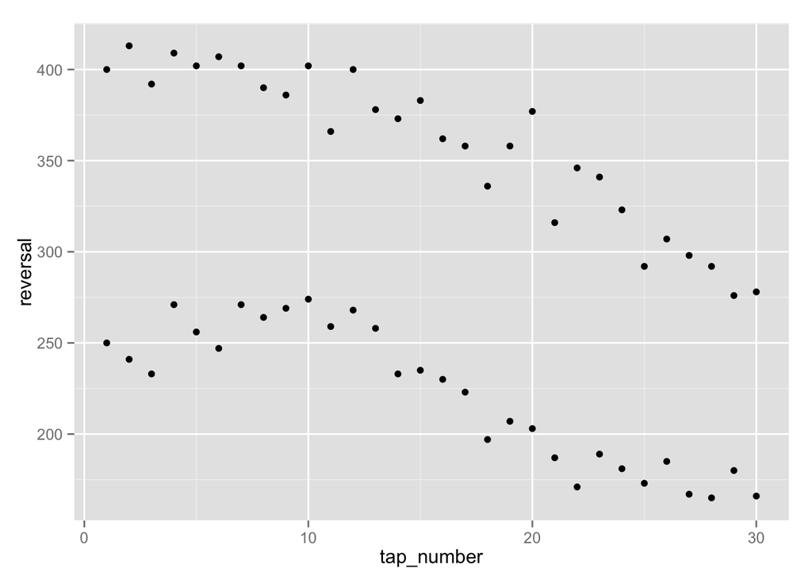

```r
#you can add layers to the plot with a +
p + geom_point() #geom_point is added to make data a scatterplot
```

#### You can also manipulate data directly in ggplot2

- All strains should respond similarly to the first tap, but we see that the two strains start at different points on the y-axis

```r
#Look at habituation data
data
```

```
##    strain tap_number reversal   N conf_int_lower conf_int_upper
## 31 mutant          1      400 440      0.8782661      0.9342585
## 32 mutant          2      413 449      0.8907261      0.9432143
## 33 mutant          3      392 454      0.8283749      0.8936691
## 34 mutant          4      409 467      0.8424208      0.9043258
## 35 mutant          5      402 479      0.8032350      0.8710057
## 36 mutant          6      407 493      0.7891201      0.8580338
## 37 mutant          7      402 492      0.7800234      0.8502592
## 38 mutant          8      390 496      0.7475513      0.8215764
## 39 mutant          9      386 497      0.7374479      0.8125439
## 40 mutant         10      402 503      0.7614870      0.8333620
## 41 mutant         11      366 504      0.6850164      0.7646878
## 42 mutant         12      400 507      0.7508128      0.8236876
## 43 mutant         13      378 496      0.7221164      0.7989201
## 44 mutant         14      373 519      0.6778710      0.7569970
```

[output cut: 46 more lines]

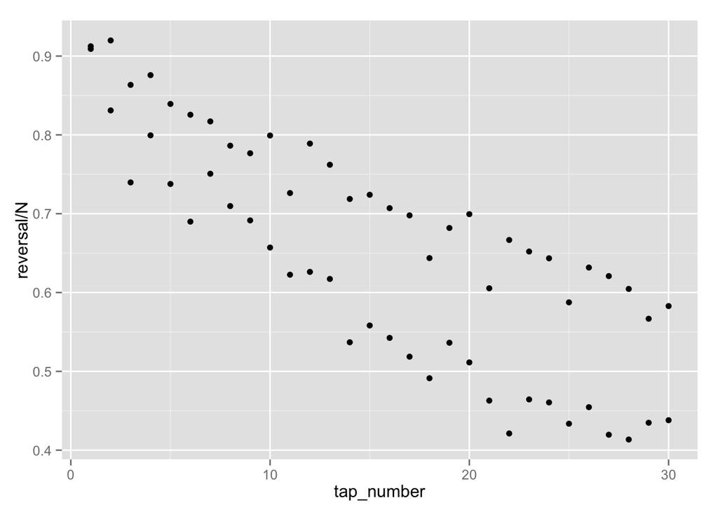

```r
#We have a column with reversal, which represents the number of worms reversing, and a column with N, which represents the total number of worms looked at during the tap
#To look at the proportion of worms reversing, we need to divide reversal by N
#This can be done directly in ggplot2

p <- ggplot(data, aes(tap_number, reversal/N)) + #Manipulate the y-axis to become reversal/N
  geom_point()
p
```

```r
#Now both strains show a similar response to the intial tap
```

#### Now we can play with aesthetics

- Aesthetics are visual properties affecting the way observations are displayed (e.g. colour, size and shape)

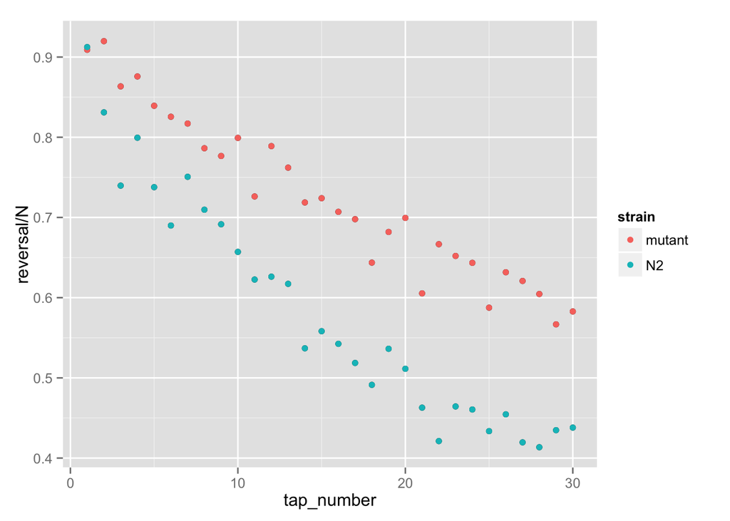

```r
#You can assign categorial variables a colour or shape and continuous variables to size

p  + geom_point(aes(colour=strain)) #Use aesthetics to colour points in scatterplot according to strain
```

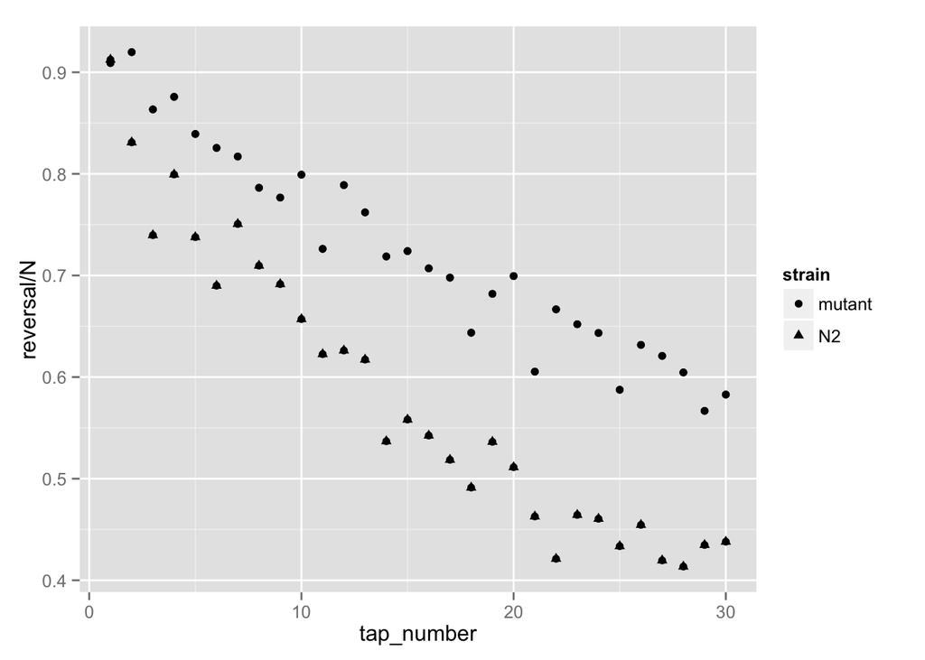

```r
p + geom_point(aes(shape=strain)) #Different shapes represent the different strains
```

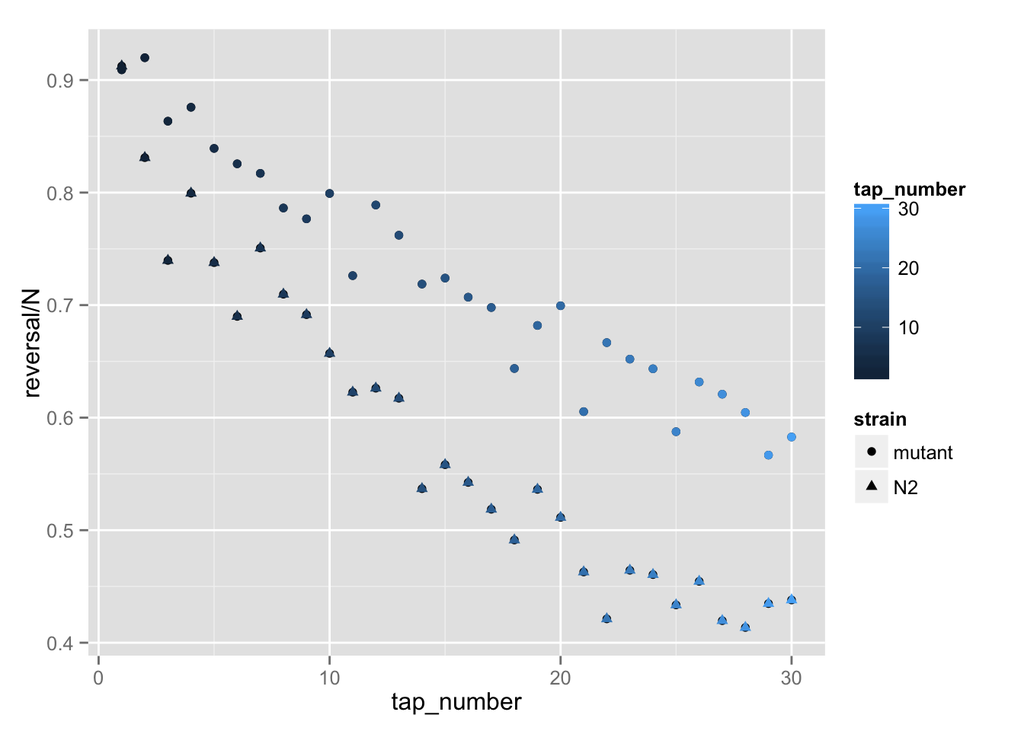

```r
p + geom_point(aes(colour=tap_number, shape=strain)) #Can string two aesthetics together using commas
```

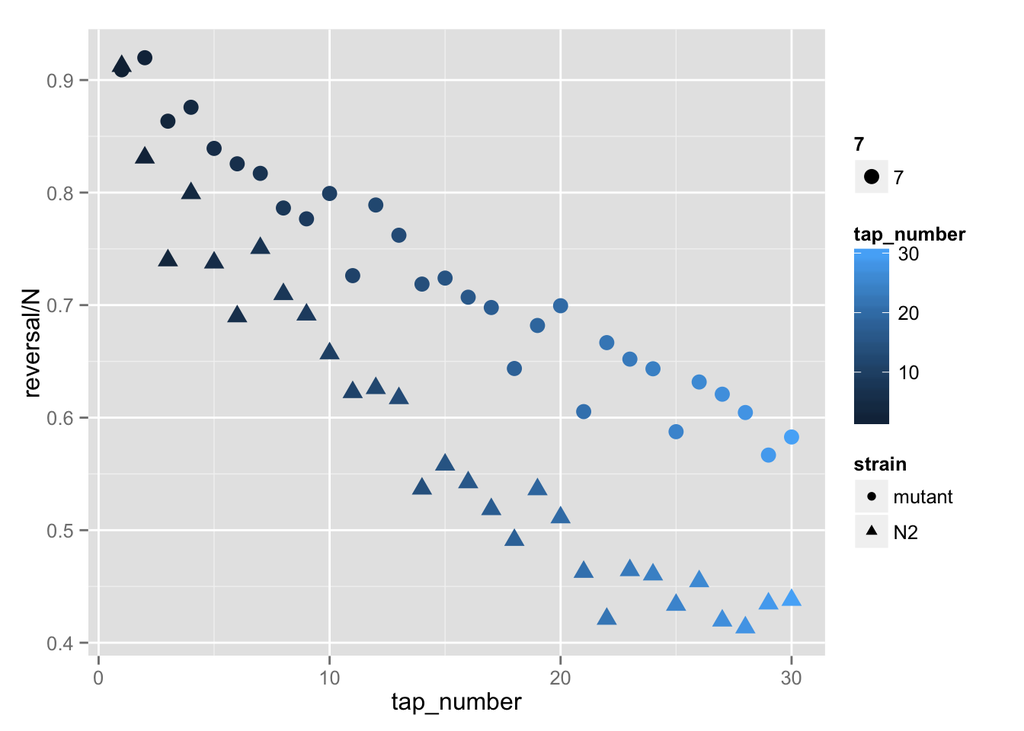

```r
p + geom_point(aes(colour=tap_number, shape=strain, size=7)) #Can also play around with size
```

#### You can also experiment with geoms to get different kinds of plots

- (e.g. scatterplot=geom_point(), line plot = geom_line(), and boxplot=geom_boxplot())

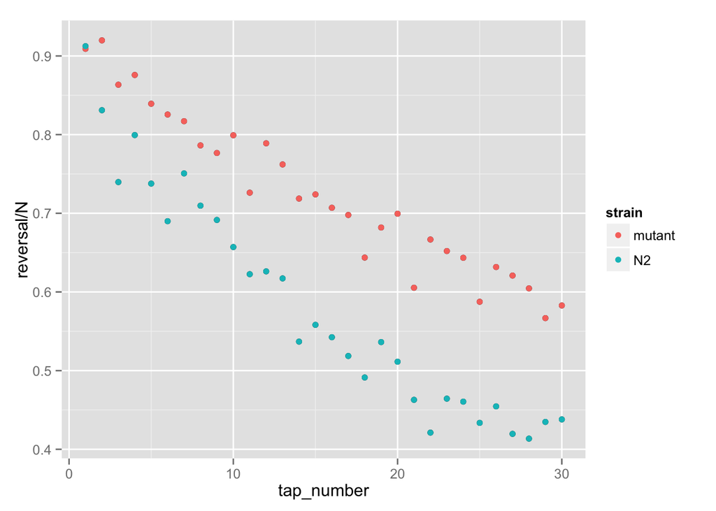

```r
p + geom_point(aes(colour=strain))
```

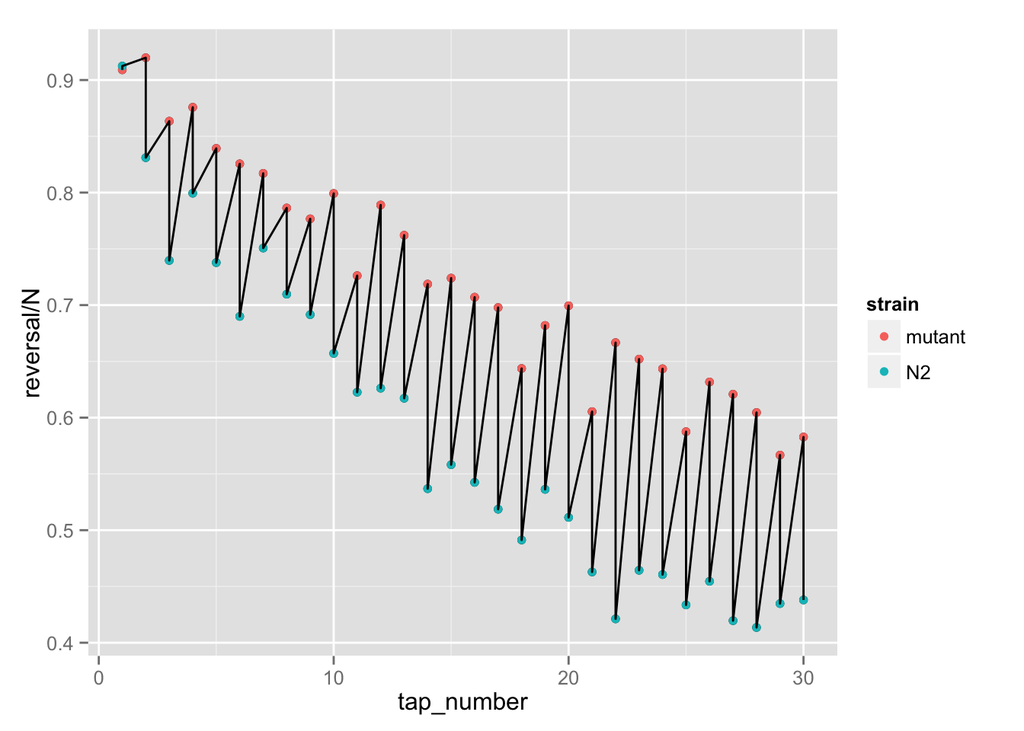

```r
p + geom_point(aes(colour=strain)) + #Can add other layers with the +
  geom_line() #Make graph a line plot
```

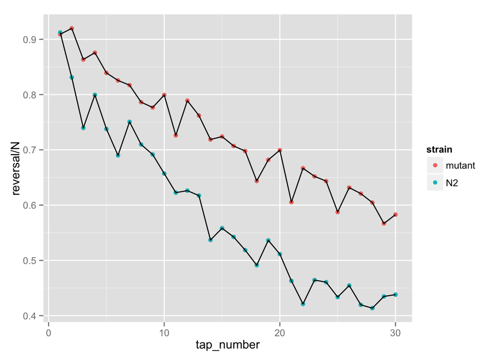

```r
p + geom_point(aes(colour=strain)) +
  geom_line(aes(group=strain)) #Add group in aesthetics to make lines attach points from the same strain
```

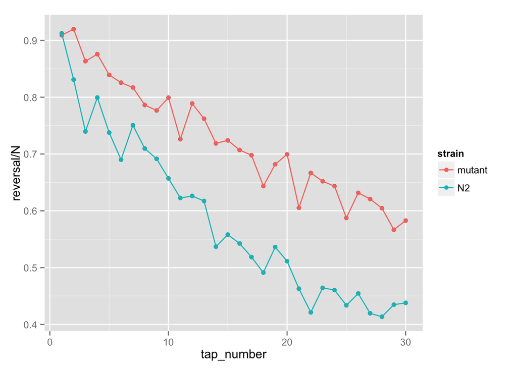

```r
p + geom_point(aes(colour=strain)) +
  geom_line(aes(colour=strain)) #Changing group to colour in aesthetics to make the lines the same colour as the points
```

## Challenge 1

Make a boxplot of strain on x-axis (categorical variable) and N (number of animals assessed) on y-axis to determine how many animals were tested

- hint: use geom_boxplot()

#### You can also add error bars to the graph

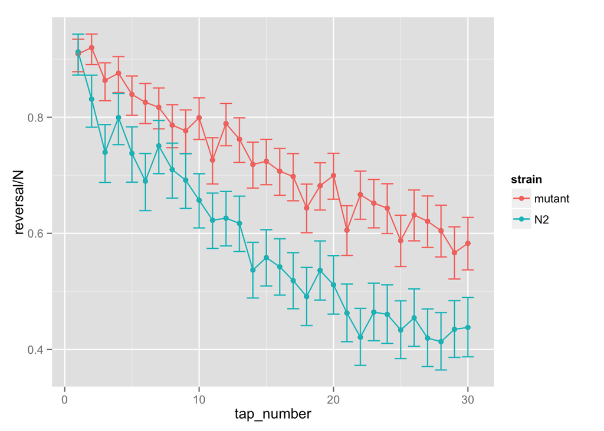

```r
p + geom_point(aes(colour=strain)) +
  geom_line(aes(colour=strain)) +
  geom_errorbar(aes(ymin=conf_int_lower, ymax=conf_int_upper, colour=strain))
```

#### Next, we can make labels (title, axes and legend)

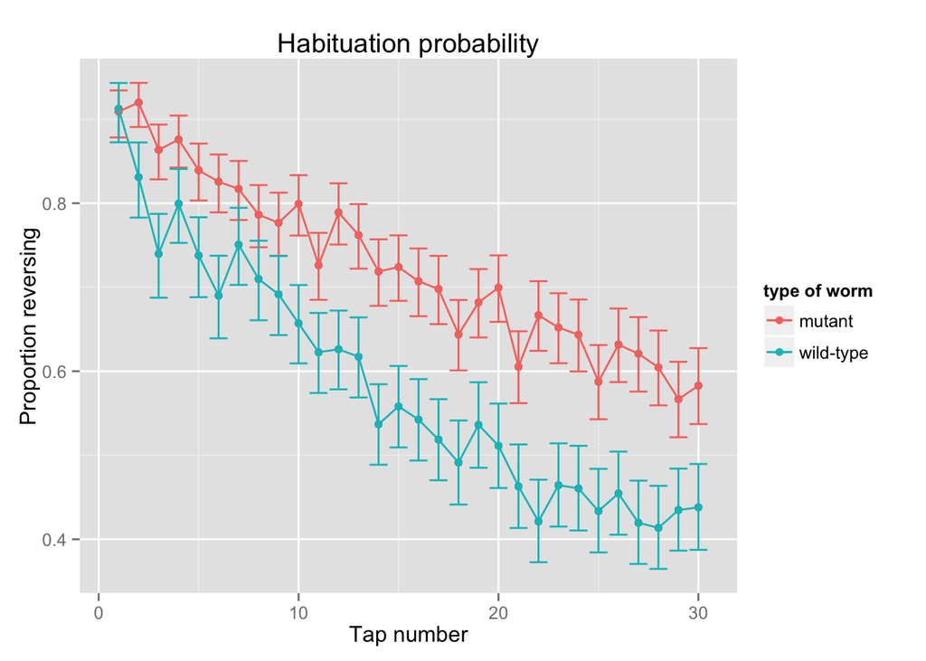

```r
p + geom_point(aes(colour=strain)) +
  geom_line(aes(colour=strain)) +
  geom_errorbar(aes(ymin=conf_int_lower, ymax=conf_int_upper, colour=strain)) +
  ggtitle("Habituation probability") + #Add title
  xlab("Tap number") + #Add x-label
  ylab("Proportion reversing") + #Add y-label
  scale_colour_hue("type of worm", #Change legend title
    breaks = c("mutant", "N2"), #Determine what strains are on the legend
    labels = c("mutant", "wild-type")) #Determine the names of the legend strains
```

#### We can also decide what values we want on our axes

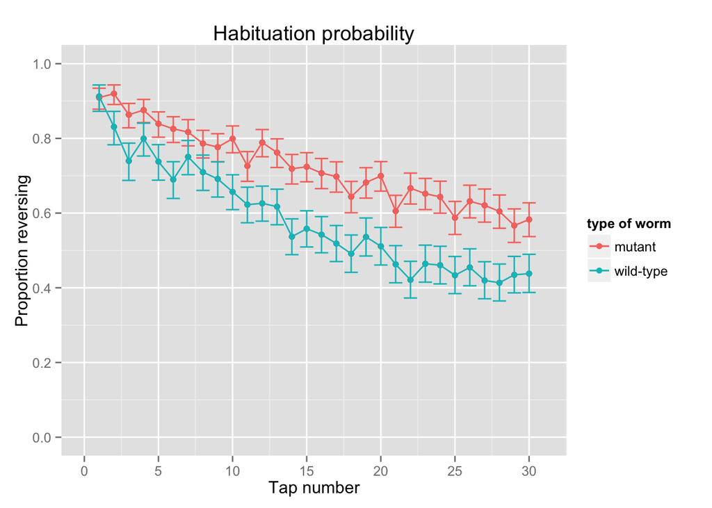

```r
p + geom_point(aes(colour=strain)) +
  geom_line(aes(colour=strain)) +
  geom_errorbar(aes(ymin=conf_int_lower, ymax=conf_int_upper, colour=strain)) +
  ggtitle("Habituation probability") + #Add title
  xlab("Tap number") + #Add x-label
  ylab("Proportion reversing") + #Add y-label
  scale_colour_hue("type of worm", #Change legend title
    breaks = c("mutant", "N2"), #Determine what strains are on the legend
    labels = c("mutant", "wild-type")) +
  scale_x_continuous(limits=c(0,31), breaks=c(0,5,10,15,20,25,30)) + #Change limits and spacing in x-axis
  scale_y_continuous(limits=c(0.0,1.0), breaks=c(0.0,0.20,0.40,0.60,0.8,1.0)) #Change limits and spacing in y-axis
```

## Challenge 2

Make a plot with tap_number on the y-axis and proportion reversing on the y-axis that only displays the last 10 taps

- hint: change limits of axis

#### Finally we can play around with the style of the graph

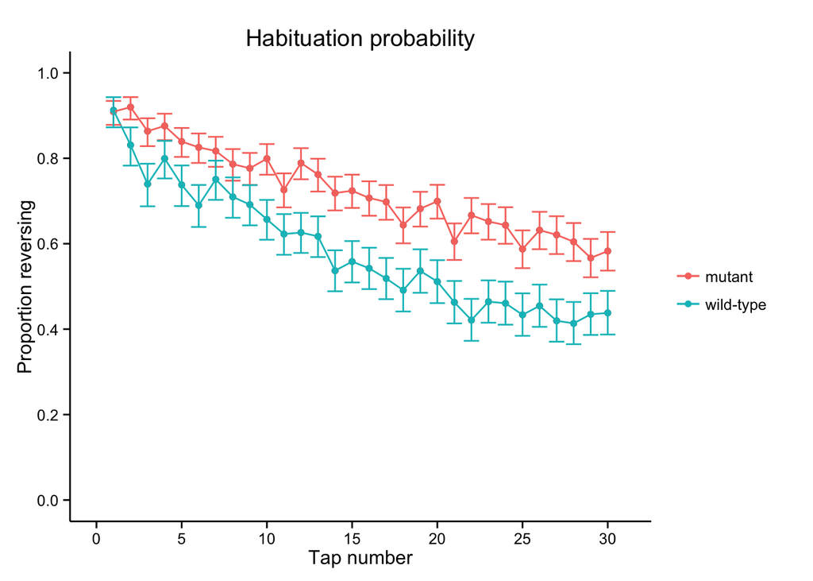

```r
p + geom_point(aes(colour=strain)) +
  geom_line(aes(colour=strain)) +
  geom_errorbar(aes(ymin=conf_int_lower, ymax=conf_int_upper, colour=strain)) +
  ggtitle("Habituation probability") + #Add title
  xlab("Tap number") + #Add x-label
  ylab("Proportion reversing") + #Add y-label
  scale_colour_hue("type of worm", #Change legend title
    breaks = c("mutant", "N2"), #Determine what strains are on the legend
    labels = c("mutant", "wild-type")) +
  scale_x_continuous(limits=c(0,31), breaks=c(0,5,10,15,20,25,30)) + #Change limits and spacing in x-axis
  scale_y_continuous(limits=c(0.0,1.0), breaks=c(0.0,0.20,0.40,0.60,0.8,1.0)) + #Change limits and spacing in y-axis
  theme_classic() + #Gives a nice white background without gridlines
  theme(legend.title=element_blank()) #Removes legend title (can override the previous manipulation of the legend)
```

Save plot

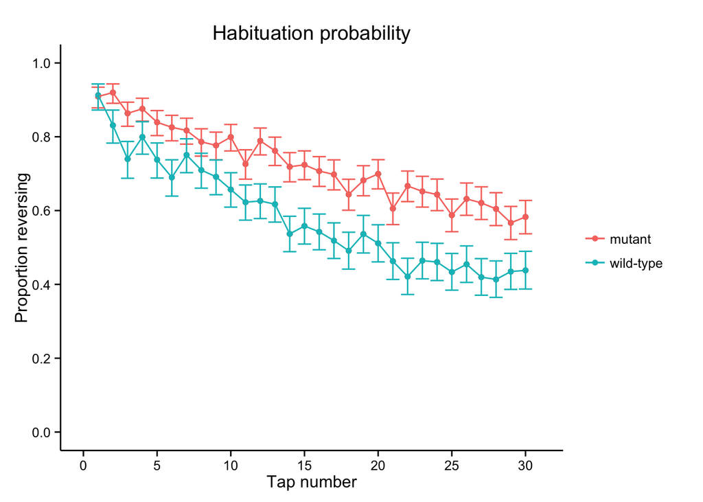

```r
p + geom_point(aes(colour=strain)) +
  geom_line(aes(colour=strain)) +
  geom_errorbar(aes(ymin=conf_int_lower, ymax=conf_int_upper, colour=strain)) +
  ggtitle("Habituation probability") + #Add title
  xlab("Tap number") + #Add x-label
  ylab("Proportion reversing") + #Add y-label
  scale_colour_hue("type of worm", #Change legend title
    breaks = c("mutant", "N2"), #Determine what strains are on the legend
    labels = c("mutant", "wild-type")) +
  scale_x_continuous(limits=c(0,31), breaks=c(0,5,10,15,20,25,30)) + #Change limits and spacing in x-axis
  scale_y_continuous(limits=c(0.0,1.0), breaks=c(0.0,0.20,0.40,0.60,0.8,1.0)) + #Change limits and spacing in y-axis
  theme_classic() +
  theme(legend.title=element_blank()) #Removes legend title
```

```r
#ggsave("final_plot.pdf", width=9, height=6)
```

### Answer to challenge 1

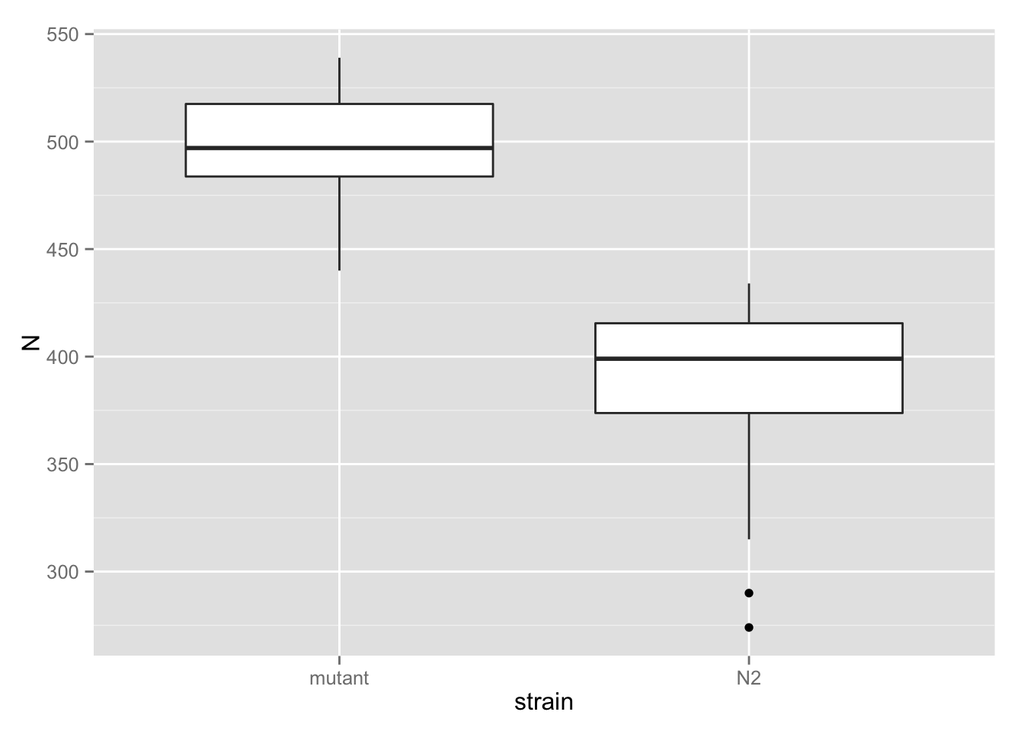

```r
ggplot(data, aes(strain, N)) +
  geom_boxplot()
```

```r
#you can also add a fill with geom_boxplot(fill="red")
```

### Answer to challenge 2

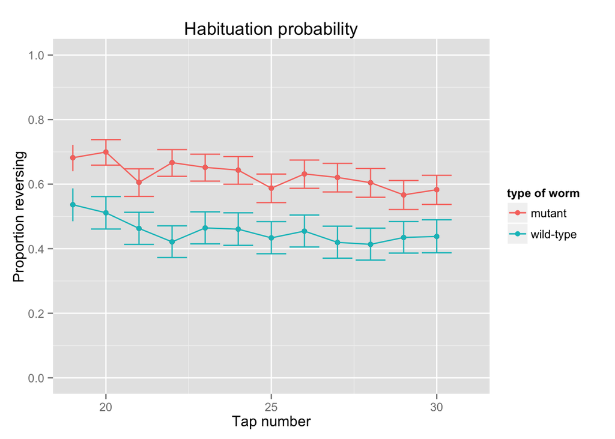

```r
p + geom_point(aes(colour=strain)) +
  geom_line(aes(colour=strain)) +
  geom_errorbar(aes(ymin=conf_int_lower, ymax=conf_int_upper, colour=strain)) +
  ggtitle("Habituation probability") + #Add title
  xlab("Tap number") + #Add x-label
  ylab("Proportion reversing") + #Add y-label
  scale_colour_hue("type of worm", #Change legend title
    breaks = c("mutant", "N2"), #Determine what strains are on the legend
    labels = c("mutant", "wild-type")) +
  scale_x_continuous(limits=c(19,31), breaks=c(20,25,30)) + #Change limits and spacing in x-axis
  scale_y_continuous(limits=c(0.0,1.0), breaks=c(0.0,0.20,0.40,0.60,0.80,1.0)) #Change limits and spacing in y-axis
```

#### Or you can subset the data ahead of time

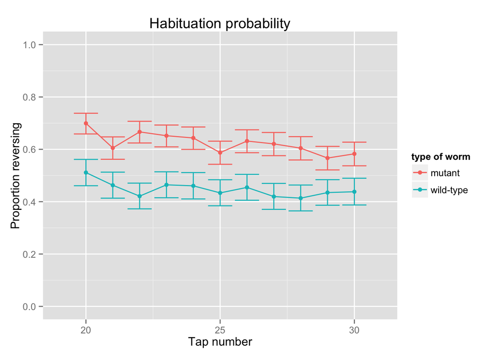

```r
ggplot(subset(data, tap_number>=20)) +
  aes(tap_number, reversal/N) +
  geom_point(aes(colour=strain)) +
  geom_line(aes(colour=strain)) +
  geom_errorbar(aes(ymin=conf_int_lower, ymax=conf_int_upper, colour=strain)) +
  ggtitle("Habituation probability") + #Add title
  xlab("Tap number") + #Add x-label
  ylab("Proportion reversing") + #Add y-label
  scale_colour_hue("type of worm", #Change legend title
    breaks = c("mutant", "N2"), #Determine what strains are on the legend
    labels = c("mutant", "wild-type")) +
  scale_x_continuous(limits=c(19,31), breaks=c(20,25,30)) + #Change limits and spacing in x-axis
  scale_y_continuous(limits=c(0.0,1.0), breaks=c(0.0,0.20,0.40,0.60,0.80,1.0)) #Change limits and spacing in y-axis
```

### Other great resources

- Book by Hadley Wickham: “ggplot2: Elegant Graphics for Data Analysis”
- ggplot2 Cheatsheet: https://www.rstudio.com/wp-content/uploads/2015/05/ggplot2-cheatsheet.pdf
- Another ggplot2 Cheatsheet: http://zevross.com/blog/2014/08/04/beautiful-plotting-in-r-a-ggplot2-cheatsheet-3/